# Chanpions Oncology - Exercise for bioinformatics candidates

Arik Ogran

3/1/2022

Useful shortcut

```r
`%notin%` <- Negate(`%in%`)
```

### Installing R base packages which are not yet installed

```r
# R Package to load
R_packages <- c("ggplot2", "stats", "dplyr", "tidyr", "ggfortify", "knitr", "lubridate", "imputeMissings", "stringr", "assist", "ggstatsplot", "forcats", "remedy",  "magrittr", "tidyverse", "devtools", "kableExtra", "pheatmap")
# Install packages not yet installed
R_packages_to_install <- R_packages %notin% rownames(installed.packages())
if (any(R_packages_to_install == TRUE)) {
  install.packages(R_packages[R_packages_to_install])
}
# R Packages loading
invisible(lapply(R_packages, library, character.only = TRUE))
```

### Installing Bioconductor packages which are not yet installed

```r
# # Bioconductor installation
# if (!requireNamespace("BiocManager", quietly = TRUE))
#   install.packages("BiocManager")
# BiocManager::install(version = "3.14")

# BioC Package to load
BioC_packages <- c("DESeq2", "edgeR","biomaRt", "EnhancedVolcano")
# Install packages not yet installed
BioC_already_exists <- installed.packages() %>% rownames() %>% devtools::package_info() %>% filter(source == "Bioconductor") %>% as.data.frame() %>% rownames()
BioC_packages_to_install <- BioC_packages %notin% BioC_already_exists
if (any(BioC_packages_to_install == TRUE)) {
  BiocManager::install(BioC_packages[BioC_packages_to_install])
}
# BioC Packages loading
invisible(lapply(BioC_packages, library, character.only = TRUE))
```

### Load the data into R and make sure the count and annotation data are consistentwith each other.

```r
# Setting working directory to hold raw data and outputs
setwd("~/iCloud/Bioinformatics courses and tools/Chanpions Oncology - Exercise for bioinformatics candidates")
counts_df <- read.delim("counts.txt")
# converting counts_df to matrix
rownames(counts_df) <- counts_df[,1]
cts <- as.matrix(counts_df[,-1])
coldata <- read.delim("sample-annotation.txt")
rownames(coldata) <- coldata[,1]
gene_anno <- read.delim("gene-annotation.txt")
rownames(gene_anno) <- gene_anno[,1]
message("Files have been loaded- count.txt, sample-annotation.txt and gene-annotation.txt")
```

```
## Files have been loaded- count.txt, sample-annotation.txt and gene-annotation.txt
```

#### Missing data: gene-annotation.txt file is missing allot of genes which are presented in the counts.txt file

```r
cat("total ensemble genes in gene-annotation.txt:", nrow(cts)) #57992 genes
```

[output not shown]

```r
cat("total non-duplicated ensemble genes in gene-annotation.txt:", rownames(cts) %>% unique() %>% length()) #57992
```

[output not shown]

```r
cat("Total genes annotated in gene-annotation.txt file:", nrow(gene_anno)) #25503 genes
```

```
## Total genes annotated in gene-annotation.txt file: 25503
```

```r
cat("Genes from counts.txt file that does not have annotation in gene-annotation.txt:", sum(rownames(cts) %notin% rownames(gene_anno))) # 32489 genes
```

```
## Genes from counts.txt file that does not have annotation in gene-annotation.txt: 32489
```

#### Fetching more gene symbols using Biomart.

Reason: In ExpressionSet, the number of rows in featureData must match the number of rows in assayData

```r
# Biomart
mart <- useMart("ENSEMBL_MART_ENSEMBL")
mart <- useDataset("hsapiens_gene_ensembl", mart)

# ensemble genes (from count.txt) to annotate by Biomart
ensLookup <- rownames(cts)

# Getting hgnc_symbol from Biomart
annotLookup <- getBM(mart=mart, attributes=c("ensembl_gene_id","gene_biotype","hgnc_symbol"), # "external_gene_name"
  filter="ensembl_gene_id",
  values=ensLookup,
  uniqueRows=TRUE)

cat(nrow(annotLookup), "genes have been annotated by Biomart") # 57051
```

```
## 57051 genes have been annotated by Biomart
```

```r
# counts.txt Genes not been annotated by Biomart
non_annotated_genes <- rownames(cts)[which(rownames(cts) %notin% annotLookup[,1])] # 944 genes
cat(length(non_annotated_genes), "counts.txt Genes not annotated by Biomart" )
```

```
## 944 counts.txt Genes not annotated by Biomart
```

```r
# adding 'non_annotated_genes' as empty row to the annotLookup by Biomart
empty_anno <- data.frame(ensembl_gene_id=non_annotated_genes, gene_biotype=rep(NA, length(non_annotated_genes)), hgnc_symbol=rep(NA, length(non_annotated_genes)))

# adding non annotated ensemble gene to the annotLookup
annotLookup_with_empty_rows <- rbind(annotLookup, empty_anno)

# Biomart exported 3 extra duplicated rows (annotations) with different 'hgnc_symbol'
cat("Biomart output of gene annotation contained", nrow(annotLookup_with_empty_rows), "rows of 57992 genes")
```

```
## Biomart output of gene annotation contained 57995 rows of 57992 genes
```

```r
# remove duplicated rows (first remained)
message("Removeing duplicated rows (first remained)")
```

```
## Removeing duplicated rows (first remained)
```

```r
annotLookup_with_empty_rows <- annotLookup_with_empty_rows %>% distinct(ensembl_gene_id, .keep_all = TRUE)
nrow(annotLookup_with_empty_rows) #finally, 57992 ensemble genes with distinct symbols
```

```
## [1] 57992
```

```r
cat("finally, 57992 ensemble genes from count.txt with distinct symbols")
```

```
## finally, 57992 ensemble genes from count.txt with distinct symbols
```

```r
#setting genes in order same as in count.txt
rownames(annotLookup_with_empty_rows) <- annotLookup_with_empty_rows$ensembl_gene_id
annotLookup_with_empty_rows <- annotLookup_with_empty_rows[rownames(cts),]
```

### Contruction of S4 object and quality control

#### Does count matrix and column data consistent in terms of sample order?

It is absolutely critical that the columns of the count matrix and the rows of the column data (information about samples) are in the same order.

```r
# Test and set samples in order in count.txt and sample-annotation.txt
if (any(!colnames(cts) == rownames(coldata))){
  cts <- cts[,rownames(coldata)]
}
if (all(rownames(coldata) == colnames(cts))){
  print("Sample order in count.txt and sample-annotation.txt is check and found consistant")
}
```

```
## [1] "Sample order in count.txt and sample-annotation.txt is check and found consistant"
```

#### ExpressionSet object building and coercion to SummarizedExperiment

```r
# setting matadata for phenoData
metadata <- data.frame(labelDescription=c("samples","skin type"),
                       row.names=c("sample_id", "type"))
phenoData <- new("AnnotatedDataFrame",data=coldata, varMetadata=metadata) # type: lesional vs normal

# setting features for gene annotations
features <- data.frame(labelDescription=c("ensembl_gene_id", "gene_biotype","hgnc_symbol"),
                       row.names=c("ensembl_gene_id", "gene_biotype","hgnc_symbol"))
annotation <- new("AnnotatedDataFrame",data=annotLookup_with_empty_rows, varMetadata=features)
# building object
GSE54456_RNAseq <- ExpressionSet(assayData=cts,
                                 phenoData=phenoData,
                                featureData=annotation)

# exprs(GSE54456_RNAseq)
# phenoData(GSE54456_RNAseq)
# sampleNames(GSE54456_RNAseq)
# featureNames(GSE54456_RNAseq)

# coercing to SummarizedExperiment
GSE54456_RNAseq_SE <- makeSummarizedExperimentFromExpressionSet(GSE54456_RNAseq)
message("ExpressionSet object has been built and coerced to SummarizedExperiment")
```

```
## ExpressionSet object has been built and coerced to SummarizedExperiment
```

```r
# setting sample type as factor
GSE54456_RNAseq_SE$type <-  as.factor(GSE54456_RNAseq_SE$type)
```

#### Subset by support: Filter the count data for lowly-expressed genes, for example, only keep genes with a CPM >= 1 in at least 75% samples, in at least one of the groups.

```r
# computing CPM
cpm <- apply(cts, 2,
             function(x) x/sum(as.numeric(x)) * 10^6)
# Check that the sum of each column (sample) after normalization equals to 10^6
# colSums(cpm)

# assign new "cpm" assay
assay(GSE54456_RNAseq_SE, "cpm") <- cpm
message("CPM has assigned to new assay of  GSE54456_RNAseq_SE SummarizedExperiment")
```

```
## CPM has assigned to new assay of  GSE54456_RNAseq_SE SummarizedExperiment
```

```r
# samples count per skin type
lesional_samples <- sum(colData(GSE54456_RNAseq_SE)$type == "lesional")
normal_samples <- sum(colData(GSE54456_RNAseq_SE)$type == "normal")

# Calculate support for lesional group
rowData(GSE54456_RNAseq_SE)$lesional_CPM_support <- as.integer(rowSums(assay(GSE54456_RNAseq_SE[,GSE54456_RNAseq_SE$type == "lesional"], "cpm") >= 1))
# Calculate support for normal group
rowData(GSE54456_RNAseq_SE)$normal_CPM_support <- as.integer(rowSums(assay(GSE54456_RNAseq_SE[,GSE54456_RNAseq_SE$type == "normal"], "cpm") >= 1))

# gene count before filtering out lowly expressed genes
before <- nrow(GSE54456_RNAseq_SE)

# Subset
GSE54456_RNAseq_SE_filtered <- GSE54456_RNAseq_SE[which(100 * (rowData(GSE54456_RNAseq_SE)$lesional_CPM_support / lesional_samples) >= 75 |
                                                  100 * (rowData(GSE54456_RNAseq_SE)$normal_CPM_support / normal_samples) >= 75)  , ]
message("Lowly-expresssed genes have been filtered out from GSE54456_RNAseq_SE ")
```

```
## Lowly-expresssed genes have been filtered out from GSE54456_RNAseq_SE
```

```r
after <- nrow(GSE54456_RNAseq_SE_filtered)
removed <- before - after

# Print summary for subset by support
message("Removed ", removed, " out of ", before, " genes (", round(removed/before * 100, digits = 1), "%)")
```

```
## Removed 39706 out of 57992 genes (68.5%)
```

### Generate an object that contains the library-size normalized log-CPM data. Saveit as a binary file (.rda or .rds).

```r
log_cpm <- apply(cts, 2,
             function(x) log(x/sum(as.numeric(x)) * 10^6))
save(log_cpm, file="logCPM.rda")
message("Binnary file of library-size normalized log-CPM data has been exported to working directory")
```

```
## Binnary file of library-size normalized log-CPM data has been exported to working directory
```

### The PCA plot may suggest the presence of outlier/mis-labeled samples in this dataset. Try to identify them and remove them from the downstream analysis.

Before performing statistical tests for various measures of Differential Expression (DE), it is important to first conduct a thorough Exploratory Data Analysis (EDA) to identify what factors we need to include in the final DE model. In this exercise case we wont look for a factor but only mis-labaled samples to remove.

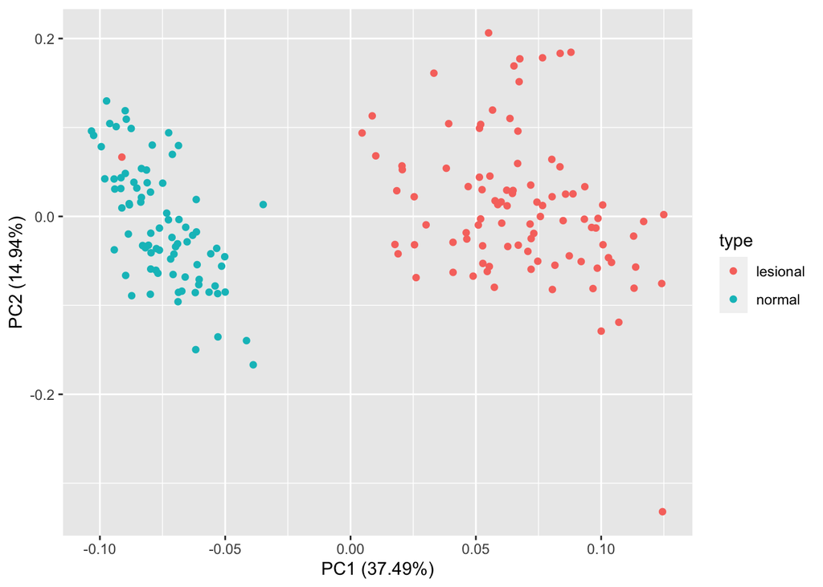

```r
# transpose the matrix
M <- t(cpm)
# transform the counts to log2 scale
M <- log2(M + 1)
# compute PCA
pcaResults <- prcomp(M)

# plot PCA results making use of ggplot2's autoplot function
# ggfortify is needed to let ggplot2 know about PCA data structure.
autoplot(pcaResults, data = coldata, colour = 'type')
```

```r
cat("Except one sample, we can be split the samples into two distinct clusters on the scatter plot based on largest principal components 1")
```

```
## Except one sample, we can be split the samples into two distinct clusters on the scatter plot based on largest principal components 1
```

```r
# identify the outlier/mis-labeled sample
mis_labeled <- rownames(pcaResults$x)[pcaResults$x[,"PC1"] < -0.05 & rownames(pcaResults$x) %in% coldata$sample_id[coldata$type == "lesional"]]

# removing outlier/mis-labeled sample/s
GSE54456_RNAseq_SE_filtered <- GSE54456_RNAseq_SE_filtered[,which(GSE54456_RNAseq_SE_filtered$sample_id != mis_labeled)]
message("outlier/mis-labeled sample has been removed")
```

```
## outlier/mis-labeled sample has been removed
```

### Differential expression analysis

Export the results in a tab-separated text/CSV file: a table with genes in rowsalongwith gene annotations and any relevant statistic.

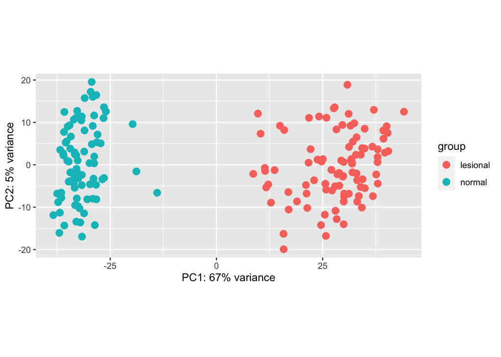

```r
# Building DESeq object from SummarizedExperiment
ddsSE <- DESeqDataSet(GSE54456_RNAseq_SE_filtered, design = ~ type)

# Normalize and log transform
vst_blind <- vst(ddsSE, blind = TRUE)
# PCA-plot of variance stabilized expression
plotPCA(vst_blind, "type")
```

```r
cat("No batch effect was found to be included in the DESeq design")
```

```
## No batch effect was found to be included in the DESeq design
```

```r
# compute the contrast for the 'type' variable where 'normal' samples are used as the control group.
# results are binded to rowData to get gene symbols
dds <- DESeq(ddsSE)
DEresults = results(dds, contrast = c("type", 'lesional', 'normal'),  tidy = TRUE) %>%
                     bind_cols(as.data.frame(rowData(GSE54456_RNAseq_SE_filtered))) %>%
                     as_tibble()
#sort results by increasing p-value
DEresults <- DEresults[order(DEresults$pvalue),]

# How many adjusted p-values were less than 0.1?
cat(sum(DEresults$padj < 0.1, na.rm=TRUE), " genes are DE with < 0.1 adjusted p-values")
```

```
## 15274  genes are DE with < 0.1 adjusted p-values
```

```r
# Exporting to results to .csv file
write.csv(DEresults,"DEresults.csv")
```

```r
# Show top 100
DEresults %>%
  top_n(n = -100, wt = padj) %>%
  dplyr::select(Gene = row,
                Symbol = hgnc_symbol,
                baseMean,
                log2FoldChange,
                padj) %>%
  kable(caption = "Top differentially expressed genes") %>%
  kable_styling(latex_options = "hold_position")
```

Top differentially expressed genes

| Gene | Symbol | baseMean | log2FoldChange | padj |
| --- | --- | --- | --- | --- |
| ENSG00000029153 | ARNTL2 | 2092.95679 | 2.169585 | 0 |
| ENSG00000057149 | SERPINB3 | 32715.18092 | 6.666896 | 0 |
| ENSG00000093134 | VNN3 | 155.29476 | 8.319209 | 0 |
| ENSG00000113749 | HRH2 | 984.72792 | 3.221389 | 0 |
| ENSG00000114251 | WNT5A | 1071.48854 | 2.479574 | 0 |
| ENSG00000115919 | KYNU | 935.86615 | 4.468396 | 0 |
| ENSG00000121316 | PLBD1 | 3435.77476 | 2.027519 | 0 |
| ENSG00000121742 | GJB6 | 10721.30782 | 2.994104 | 0 |
| ENSG00000134827 | TCN1 | 2567.58545 | 7.994447 | 0 |
| ENSG00000136688 | IL36G | 4944.01970 | 5.666276 | 0 |
| ENSG00000140519 | RHCG | 7313.98973 | 5.278936 | 0 |
| ENSG00000146242 | TPBG | 1582.79809 | 1.789753 | 0 |
| ENSG00000153802 | TMPRSS11D | 984.39828 | 7.709845 | 0 |
| ENSG00000159337 | PLA2G4D | 7336.31795 | 4.613827 | 0 |
| ENSG00000163202 | LCE3D | 11768.68764 | 5.332025 | 0 |
| ENSG00000163216 | SPRR2D | 29776.20167 | 5.920731 | 0 |
| ENSG00000163221 | S100A12 | 625.52950 | 8.242576 | 0 |
| ENSG00000163874 | ZC3H12A | 4206.87778 | 3.804233 | 0 |
| ENSG00000164687 | FABP5 | 12467.34273 | 3.617986 | 0 |
| ENSG00000165474 | GJB2 | 42771.11372 | 4.383109 | 0 |
| ENSG00000167759 | KLK13 | 3000.91568 | 4.029151 | 0 |
| ENSG00000173083 | HPSE | 1414.77359 | 2.878862 | 0 |
| ENSG00000174808 | BTC | 395.40304 | -4.378219 | 0 |
| ENSG00000176749 | CDK5R1 | 331.06790 | 2.309098 | 0 |
| ENSG00000176797 | DEFB103A | 962.70424 | 5.970828 | 0 |
| ENSG00000184060 | ADAP2 | 1220.61137 | 2.044897 | 0 |
| ENSG00000184731 | FAM110C | 1082.24632 | 2.094780 | 0 |
| ENSG00000188373 | C10orf99 | 2560.12267 | 5.490576 | 0 |
| ENSG00000196805 | SPRR2B | 22064.23370 | 6.288347 | 0 |
| ENSG00000198074 | AKR1B10 | 2824.18490 | 6.227062 | 0 |

[output cut: 70 more lines]

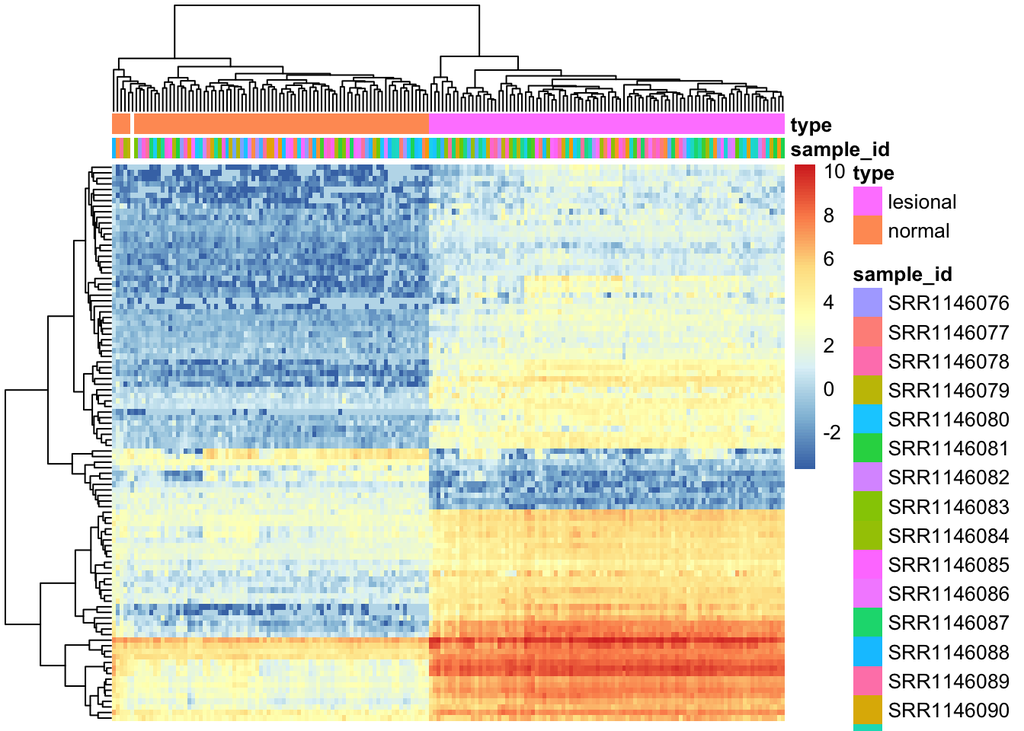

```r
# Top 100
Top_100 <- DEresults %>% arrange (desc(abs(log2FoldChange))) %>% head (100)

# log_cpm pheatmap:
# Since Count data was filtered to hold genes that expressed in >= 1 CPM in at list 75% of samples, some genes have zero count in some samples which result in log_CPM as -INF.
# In order to pheatmap log_cpm, -Inf values must be changed to 0
noInf <- log_cpm
noInf[which(!is.finite(noInf))] <- 0
# setting annotation_col
df <- as.data.frame(colData(ddsSE)[,c("sample_id","type")])
# ploting pheatmap
pheatmap(noInf[Top_100$row,], cluster_rows=TRUE, show_rownames=FALSE, show_colnames=FALSE,
         cluster_cols=T, annotation_col=df)
```

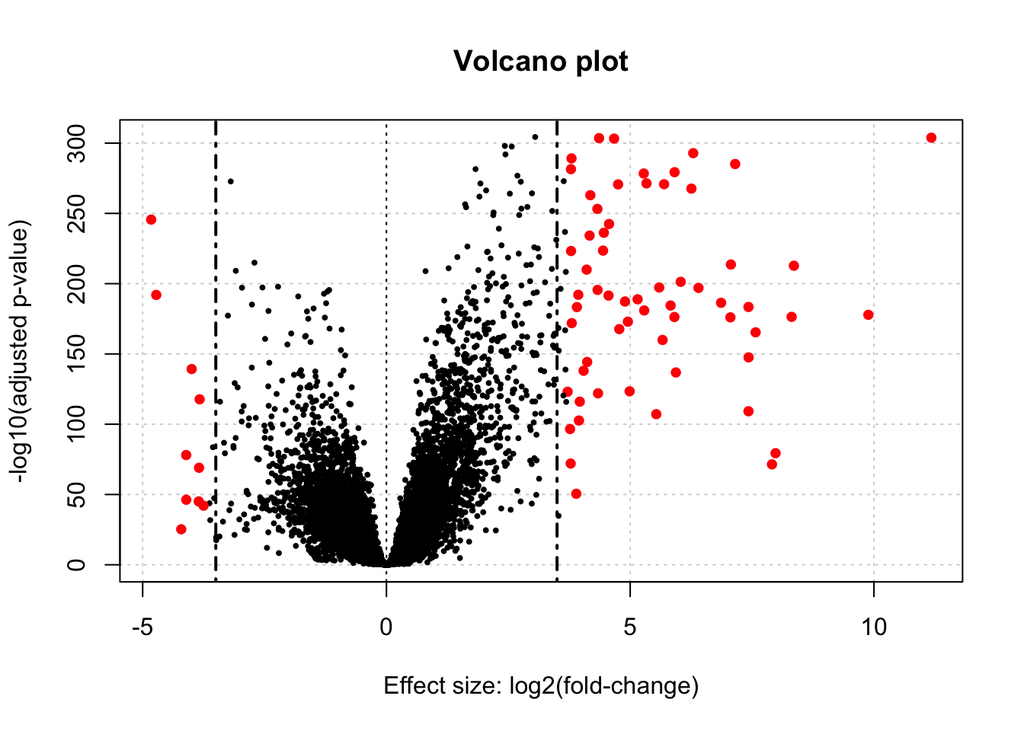

```r
# setting red color  and size for top 100 DE genes
cols <- ifelse(DEresults$row %in% Top_100$row, 'red', 'black')
size <- ifelse(DEresults$row %in% Top_100$row, 1.2, 0.6)
# plotting volcano
plot(DEresults$log2FoldChange, -log10(DEresults$padj), col=cols, panel.first=grid(),
     main="Volcano plot", xlab="Effect size: log2(fold-change)", ylab="-log10(adjusted p-value)",
     pch=20, cex=size)
abline(v=0, col="black", lty=3, lwd=1.0)
abline(v=3.5, col="black", lty=4, lwd=2.0)
abline(v=-3.5, col="black", lty=4, lwd=2.0)
```